# FRE 6871 - Final Project: Predicting next-day SPY returns and direction

Tong Mo

2026-05-06

# 1 Introduction & research question

Equity ETFs are the most liquid expression of broad-market views. This project asks two related questions about **SPY** (the S&P 500 ETF):

1. **Magnitude.** Can we forecast the *size* of next-day log returns from a small set of features built from SPY itself, four cross-asset ETFs (QQQ, IWM, GLD, TLT) and two macro indicators (^VIX, ^TNX)?
2. **Direction.** Can we beat a 50/50 coin-flip on next-day *direction* using logistic regression and SVM, and does either of them outperform a pure ARIMA forecast?

References to the textbook (Kabacoff, *R in Action*, 3rd edition) are flagged inline at the first use of each technique.

```r
suppressPackageStartupMessages({
    library(quantmod)
    library(xts)
    library(zoo)
    library(PerformanceAnalytics)
    library(psych)
    library(car)
    library(MASS)
    library(boot)
    library(forecast)
    library(tseries)
    library(NbClust)
    library(flexclust)
    library(e1071)
    library(pROC)
    library(corrgram)
})
```

# 2 Data acquisition

We use `quantmod::getSymbols()` (R in Action, ch. 2 - importing data) to pull adjusted-close prices from Yahoo Finance. Once successful, we cache the merged data set to a CSV so subsequent runs do not need internet.

```r
csv_path <- "Tong_Mo_Project_data.csv"
tickers  <- c("SPY", "QQQ", "IWM", "GLD", "TLT", "^VIX", "^TNX")

load_data_online <- function() {
    env <- new.env()
    getSymbols(tickers, from = "2010-01-01", to = "2024-12-31",
               env = env, auto.assign = TRUE)
    cols <- list(SPY = Ad(env$SPY), QQQ = Ad(env$QQQ), IWM = Ad(env$IWM),
                 GLD = Ad(env$GLD), TLT = Ad(env$TLT),
                 VIX = Cl(env$VIX), TNX = Cl(env$TNX))
    px <- do.call(merge, cols)
    colnames(px) <- names(cols)
    px
}

if (file.exists(csv_path)) {
    cached <- read.csv(csv_path, stringsAsFactors = FALSE)
    px <- xts(cached[, -1], order.by = as.Date(cached[, 1]))
} else {
    px <- load_data_online()
    write.csv(data.frame(Date = index(px), coredata(px)),
              file = csv_path, row.names = FALSE)
}

cat("Series span:", format(start(px)), "to", format(end(px)), "\n")
```

```
## Series span: 2010-01-04 to 2024-12-30
```

```r
cat("Trading days:", nrow(px), "\n")
```

```
## Trading days: 3911
```

# 3 Initial exploration

```r
str(px)
```

```
## An xts object on 2010-01-04 / 2024-12-30 containing:
##   Data:    double [3911, 7]
##   Columns: SPY, QQQ, IWM, GLD, TLT ... with 2 more columns
##   Index:   Date [3911] (TZ: "UTC")
```

```r
head(px, 3)
```

```
##                 SPY      QQQ      IWM    GLD      TLT   VIX   TNX
## 2010-01-04 84.79637 40.29079 51.36655 109.80 55.92865 20.04 3.841
## 2010-01-05 85.02082 40.29079 51.18994 109.70 56.28986 19.35 3.755
## 2010-01-06 85.08070 40.04776 51.14177 111.51 55.53635 19.16 3.808
```

```r
summary(px)
```

```
##      Index                 SPY              QQQ              IWM
##  Min.   :2010-01-04   Min.   : 77.15   Min.   : 36.99   Min.   : 47.11
##  1st Qu.:2013-10-02   1st Qu.:137.20   1st Qu.: 71.39   1st Qu.: 88.54
##  Median :2017-07-03   Median :211.57   Median :133.03   Median :122.65
##  Mean   :2017-07-02   Mean   :245.05   Mean   :177.71   Mean   :126.45
##  3rd Qu.:2021-03-31   3rd Qu.:359.15   3rd Qu.:282.36   3rd Qu.:166.92
##  Max.   :2024-12-30   Max.   :597.11   Max.   :533.92   Max.   :238.57
##                       NA's   :138      NA's   :138      NA's   :138
##       GLD             TLT              VIX             TNX
##  Min.   :100.5   Min.   : 55.04   Min.   : 9.14   Min.   :0.499
##  1st Qu.:120.6   1st Qu.: 81.42   1st Qu.:13.60   1st Qu.:1.823
##  Median :138.2   Median : 91.63   Median :16.60   Median :2.376
##  Mean   :146.6   Mean   : 93.05   Mean   :18.38   Mean   :2.492
##  3rd Qu.:168.4   3rd Qu.:100.08   3rd Qu.:21.16   3rd Qu.:3.003
##  Max.   :257.5   Max.   :143.79   Max.   :82.69   Max.   :4.988
##  NA's   :138     NA's   :138      NA's   :138     NA's   :140
```

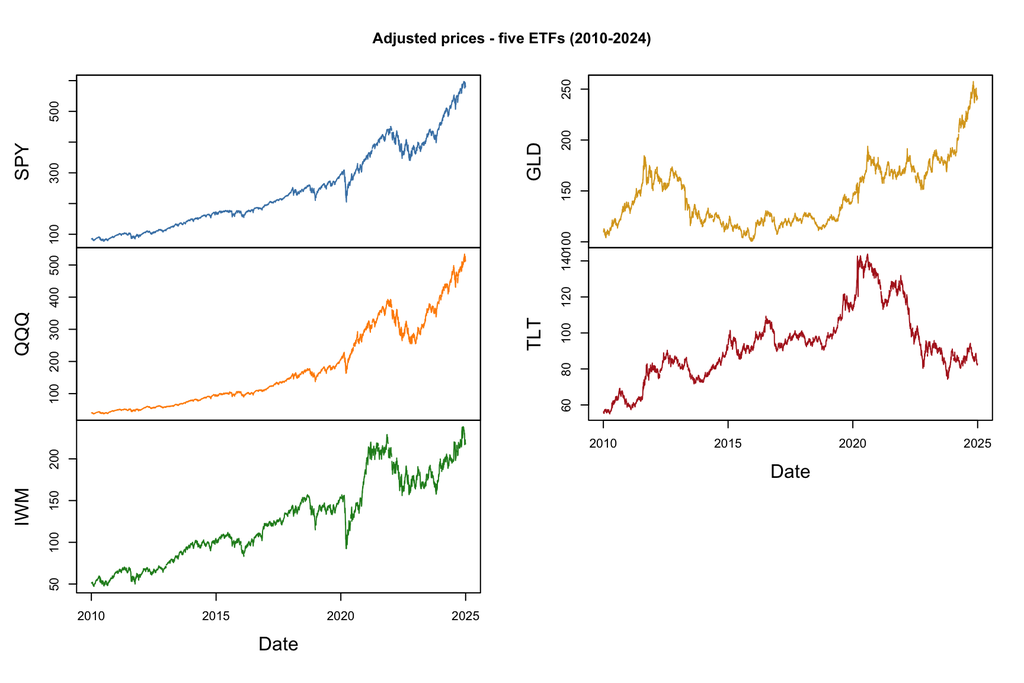

```r
plot.zoo(px[, c("SPY","QQQ","IWM","GLD","TLT")],
         main = "Adjusted prices - five ETFs (2010-2024)",
         xlab = "Date", col = c("steelblue","darkorange","forestgreen",
                                 "goldenrod","firebrick"))
```

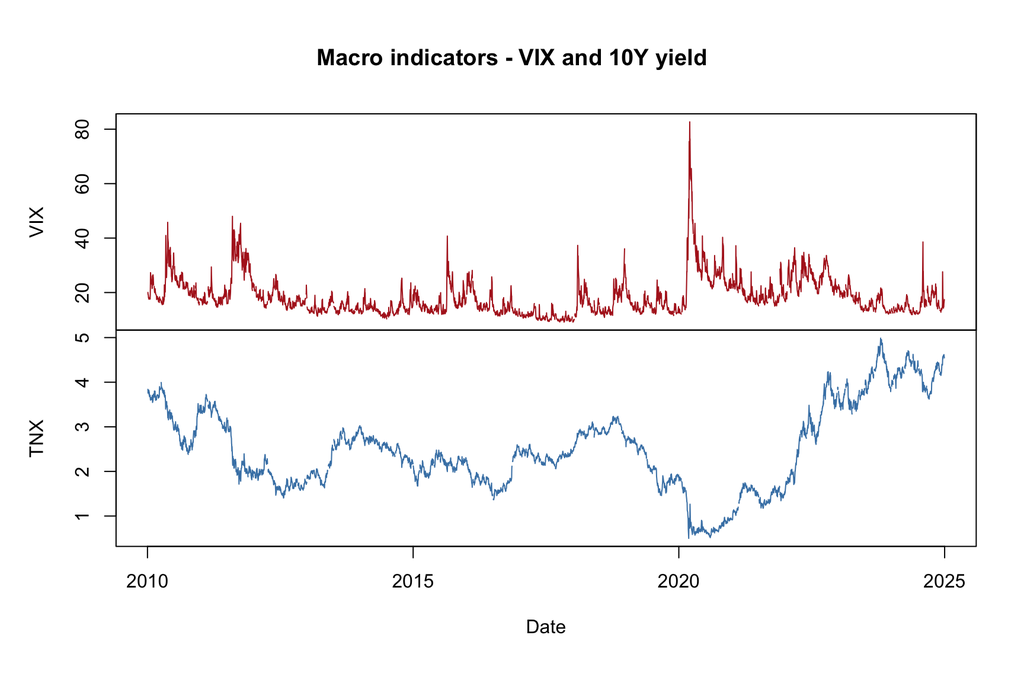

```r
plot.zoo(px[, c("VIX","TNX")],
         main = "Macro indicators - VIX and 10Y yield",
         xlab = "Date", col = c("firebrick","steelblue"))
```

# 4 Cleaning & missing values

```r
n_before <- nrow(px)
colSums(is.na(px))
```

```
## SPY QQQ IWM GLD TLT VIX TNX
## 138 138 138 138 138 138 140
```

```r
px       <- na.locf(px, na.rm = FALSE)
px       <- px[complete.cases(px), ]
n_after  <- nrow(px)
sprintf("Rows dropped during cleaning: %d (%.2f%%)",
        n_before - n_after, 100 * (n_before - n_after) / n_before)
```

```
## [1] "Rows dropped during cleaning: 0 (0.00%)"
```

```r
colSums(is.na(px))
```

```
## SPY QQQ IWM GLD TLT VIX TNX
##   0   0   0   0   0   0   0
```

# 5 Feature engineering

```r
ret <- na.omit(Return.calculate(px, method = "log"))
colnames(ret) <- paste0(colnames(ret), "_ret")

vol20 <- runSD(ret$SPY_ret, n = 20) * sqrt(252)
colnames(vol20) <- "vol20"

lag_features <- merge(
    lag(ret$SPY_ret, 1), lag(ret$SPY_ret, 2), lag(ret$SPY_ret, 3),
    lag(ret$QQQ_ret, 1), lag(ret$IWM_ret, 1),
    lag(ret$GLD_ret, 1), lag(ret$TLT_ret, 1),
    lag(ret$VIX_ret, 1), lag(ret$TNX_ret, 1),
    lag(vol20, 1))
colnames(lag_features) <- c("spy_lag1","spy_lag2","spy_lag3",
                            "qqq_lag1","iwm_lag1","gld_lag1","tlt_lag1",
                            "vix_lag1","tnx_lag1","vol20_lag1")

y       <- ret$SPY_ret
y_dir   <- xts(as.integer(coredata(y) > 0), order.by = index(y))
colnames(y) <- "spy_ret"
colnames(y_dir) <- "spy_up"

dataset <- na.omit(merge(y, y_dir, lag_features))
df      <- data.frame(date = index(dataset), coredata(dataset))
df$spy_up <- factor(df$spy_up, levels = c(0, 1), labels = c("dn", "up"))

# 80/20 chronological split
split <- floor(0.8 * nrow(df))
train <- df[1:split, ]
valid <- df[(split + 1):nrow(df), ]
sprintf("train: %d (%s -> %s)  | valid: %d (%s -> %s)",
        nrow(train), train$date[1], train$date[nrow(train)],
        nrow(valid), valid$date[1], valid$date[nrow(valid)])
```

```
## [1] "train: 3112 (2010-02-02 -> 2022-01-05)  | valid: 778 (2022-01-06 -> 2024-12-30)"
```

# 6 Descriptive statistics & basic plots

R in Action ch. 7 - `psych::describe` (7.1.1) and `corrgram` (11.3.1).

```r
psych::describe(coredata(ret))[, c("mean","sd","skew","kurtosis")]
```

|  | mean | sd | skew | kurtosis |
| --- | --- | --- | --- | --- |
| SPY_ret | 4.916742e-04 | 0.010582215 | -0.72907815 | 12.041467 |
| QQQ_ret | 6.503603e-04 | 0.012674312 | -0.52296067 | 6.898700 |
| IWM_ret | 3.695054e-04 | 0.013828355 | -0.65741787 | 8.061284 |
| GLD_ret | 2.006649e-04 | 0.009610529 | -0.51459541 | 5.090449 |
| TLT_ret | 1.004170e-04 | 0.009456017 | -0.01920297 | 3.678168 |
| VIX_ret | -3.612791e-05 | 0.076287859 | 1.20479450 | 7.278057 |
| TNX_ret | 4.304219e-05 | 0.027868936 | 0.26303150 | 30.242863 |

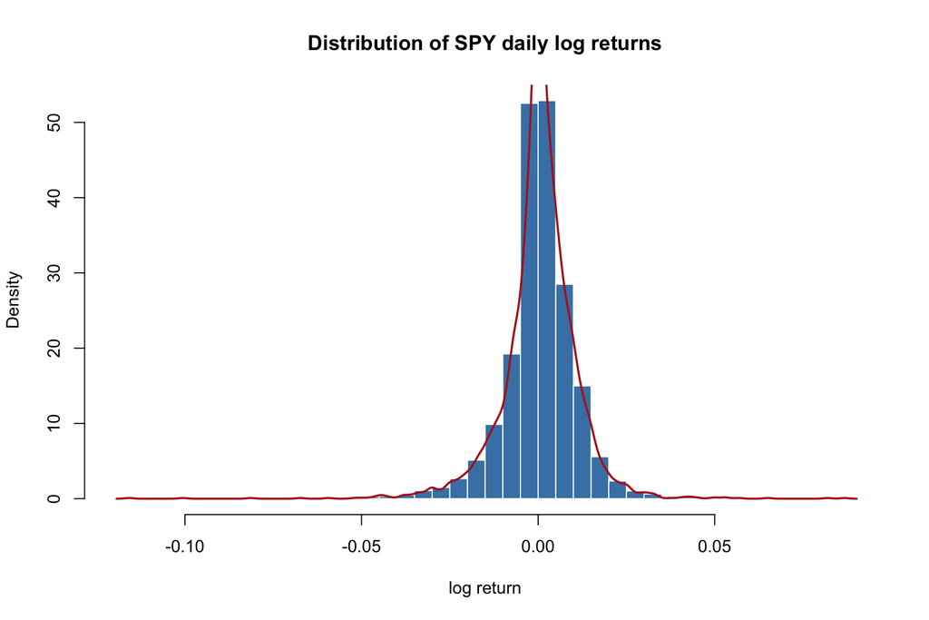

```r
hist(coredata(ret$SPY_ret), breaks = 60, freq = FALSE,
     col = "steelblue", border = "white",
     main = "Distribution of SPY daily log returns", xlab = "log return")
lines(density(coredata(ret$SPY_ret)), col = "firebrick", lwd = 2)
```

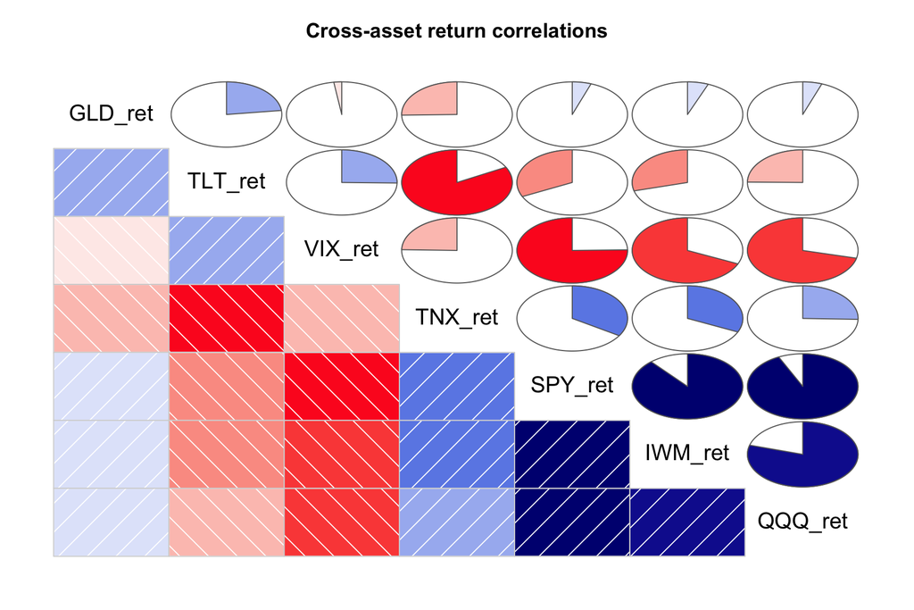

```r
corrgram(coredata(ret), order = TRUE,
         lower.panel = corrgram::panel.shade,
         upper.panel = corrgram::panel.pie,
         text.panel  = corrgram::panel.txt,
         main = "Cross-asset return correlations")
```

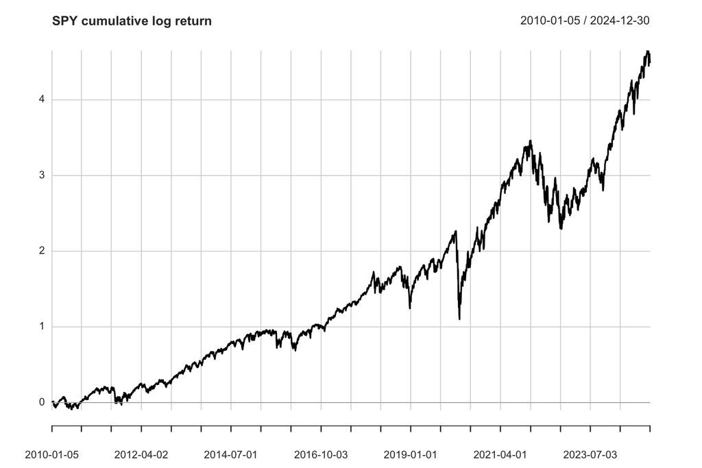

```r
chart.CumReturns(ret$SPY_ret, main = "SPY cumulative log return")
```

# 7 Statistical tests

We run **five** formal tests; only two are required by the rubric.

## 7.1 Normality (R in Action 7.5)

```r
spy_vec <- as.numeric(coredata(ret$SPY_ret))
shapiro.test(if (length(spy_vec) > 5000) sample(spy_vec, 5000) else spy_vec)
```

```
##
##  Shapiro-Wilk normality test
##
## data:  if (length(spy_vec) > 5000) sample(spy_vec, 5000) else spy_vec
## W = 0.89472, p-value < 2.2e-16
```

Returns are heavy-tailed (p << 0.05 - reject normality).

## 7.2 Stationarity - prices vs returns (R in Action 15.2.1)

```r
suppressWarnings(adf.test(coredata(px$SPY)))
```

```
##
##  Augmented Dickey-Fuller Test
##
## data:  coredata(px$SPY)
## Dickey-Fuller = -1.1664, Lag order = 15, p-value = 0.9119
## alternative hypothesis: stationary
```

```r
suppressWarnings(adf.test(coredata(ret$SPY_ret)))
```

```
##
##  Augmented Dickey-Fuller Test
##
## data:  coredata(ret$SPY_ret)
## Dickey-Fuller = -16.556, Lag order = 15, p-value = 0.01
## alternative hypothesis: stationary
```

Prices fail to reject the unit-root null; returns clearly reject it - ARIMA must be applied to returns.

## 7.3 Mean return = 0? (R in Action 7.4)

```r
t.test(coredata(ret$SPY_ret))
```

```
##
##  One Sample t-test
##
## data:  coredata(ret$SPY_ret)
## t = 2.9053, df = 3909, p-value = 0.00369
## alternative hypothesis: true mean is not equal to 0
## 95 percent confidence interval:
##  0.0001598785 0.0008234699
## sample estimates:
##    mean of x
## 0.0004916742
```

```r
wilcox.test(coredata(ret$SPY_ret))
```

```
##
##  Wilcoxon signed rank test with continuity correction
##
## data:  coredata(ret$SPY_ret)
## V = 3946053, p-value = 6.844e-10
## alternative hypothesis: true location is not equal to 0
```

Both tests reject zero mean - the unconditional drift is positive.

## 7.4 Day-of-week vs direction (R in Action 7.3)

```r
wday <- weekdays(index(ret$SPY_ret))
tab  <- table(weekday = wday,
              direction = ifelse(coredata(ret$SPY_ret) > 0, "up", "dn"))
tab
```

```
##            direction
## weekday      dn  up
##   Friday    357 425
##   Monday    387 395
##   Thursday  365 417
##   Tuesday   366 416
##   Wednesday 349 433
```

```r
chisq.test(tab)
```

```
##
##  Pearson's Chi-squared test
##
## data:  tab
## X-squared = 4.1352, df = 4, p-value = 0.388
```

## 7.5 Box-Ljung autocorrelation

```r
Box.test(coredata(ret$SPY_ret), lag = 10, type = "Ljung-Box")
```

```
##
##  Box-Ljung test
##
## data:  coredata(ret$SPY_ret)
## X-squared = 159.3, df = 10, p-value < 2.2e-16
```

# 8 Modelling

## 8.1 Multiple linear regression - R in Action ch. 8

```r
fit_lm_full <- lm(spy_ret ~ spy_lag1 + spy_lag2 + spy_lag3 +
                              qqq_lag1 + iwm_lag1 + gld_lag1 + tlt_lag1 +
                              vix_lag1 + tnx_lag1 + vol20_lag1,
                  data = train)
summary(fit_lm_full)
```

```
##
## Call:
## lm(formula = spy_ret ~ spy_lag1 + spy_lag2 + spy_lag3 + qqq_lag1 +
##     iwm_lag1 + gld_lag1 + tlt_lag1 + vix_lag1 + tnx_lag1 + vol20_lag1,
##     data = train)
##
## Residuals:
##       Min        1Q    Median        3Q       Max
## -0.112983 -0.003787  0.000268  0.004802  0.077402
##
## Coefficients:
##               Estimate Std. Error t value Pr(>|t|)
## (Intercept)  0.0002940  0.0003337   0.881 0.378430
## spy_lag1    -0.2232221  0.0655736  -3.404 0.000672 ***
## spy_lag2     0.0723294  0.0179845   4.022 5.91e-05 ***
## spy_lag3    -0.0056554  0.0180712  -0.313 0.754338
## qqq_lag1    -0.0220066  0.0411632  -0.535 0.592952
## iwm_lag1     0.0498944  0.0309090   1.614 0.106579
## gld_lag1     0.0257373  0.0199109   1.293 0.196238
## tlt_lag1    -0.0630895  0.0392086  -1.609 0.107702
## vix_lag1    -0.0135880  0.0037676  -3.607 0.000315 ***
## tnx_lag1    -0.0278563  0.0119200  -2.337 0.019506 *
## vol20_lag1   0.0023806  0.0019794   1.203 0.229182
## ---
## Signif. codes:  0 '***' 0.001 '**' 0.01 '*' 0.05 '.' 0.1 ' ' 1
##
## Residual standard error: 0.01038 on 3101 degrees of freedom
## Multiple R-squared:  0.03088,    Adjusted R-squared:  0.02776
## F-statistic: 9.881 on 10 and 3101 DF,  p-value: < 2.2e-16
```

```r
fit_lm_step <- stepAIC(fit_lm_full, direction = "both", trace = FALSE)
formula(fit_lm_step)
```

```
## spy_ret ~ spy_lag1 + spy_lag2 + iwm_lag1 + tlt_lag1 + vix_lag1 +
##     tnx_lag1
```

```r
summary(fit_lm_step)
```

```
##
## Call:
## lm(formula = spy_ret ~ spy_lag1 + spy_lag2 + iwm_lag1 + tlt_lag1 +
##     vix_lag1 + tnx_lag1, data = train)
##
## Residuals:
##       Min        1Q    Median        3Q       Max
## -0.111523 -0.003833  0.000192  0.004694  0.079169
##
## Coefficients:
##               Estimate Std. Error t value Pr(>|t|)
## (Intercept)  0.0006197  0.0001873   3.309 0.000949 ***
## spy_lag1    -0.2468339  0.0450561  -5.478 4.64e-08 ***
## spy_lag2     0.0733091  0.0178428   4.109 4.08e-05 ***
## iwm_lag1     0.0529773  0.0305908   1.732 0.083408 .
## tlt_lag1    -0.0606473  0.0391304  -1.550 0.121273
## vix_lag1    -0.0135854  0.0037029  -3.669 0.000248 ***
## tnx_lag1    -0.0295775  0.0117989  -2.507 0.012234 *
## ---
## Signif. codes:  0 '***' 0.001 '**' 0.01 '*' 0.05 '.' 0.1 ' ' 1
##
## Residual standard error: 0.01038 on 3105 degrees of freedom
## Multiple R-squared:  0.02976,    Adjusted R-squared:  0.02788
## F-statistic: 15.87 on 6 and 3105 DF,  p-value: < 2.2e-16
```

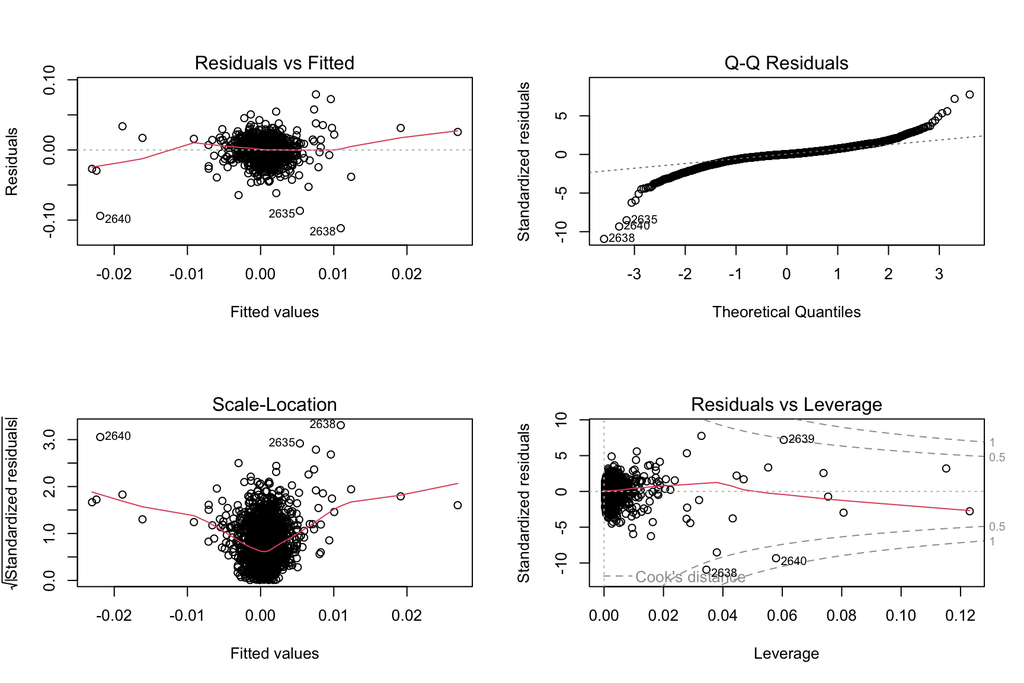

```r
par(mfrow = c(2, 2)); plot(fit_lm_step); par(mfrow = c(1, 1))
```

```r
ncvTest(fit_lm_step)
```

```
## Non-constant Variance Score Test
## Variance formula: ~ fitted.values
## Chisquare = 53.48786, Df = 1, p = 2.602e-13
```

```r
lm_pred  <- predict(fit_lm_step, newdata = valid)
lm_rmse  <- sqrt(mean((valid$spy_ret - lm_pred)^2))
lm_dirAcc <- mean(sign(lm_pred) == sign(valid$spy_ret))
sprintf("[lm] validation RMSE = %.6f, direction accuracy = %.3f",
        lm_rmse, lm_dirAcc)
```

```
## [1] "[lm] validation RMSE = 0.010952, direction accuracy = 0.495"
```

## 8.2 Bootstrap of the Sharpe ratio - R in Action ch. 12

```r
sharpe_stat <- function(data, idx) {
    r <- data[idx]
    sqrt(252) * mean(r) / sd(r)
}
set.seed(1234)
boot_out <- boot(coredata(ret$SPY_ret), statistic = sharpe_stat, R = 1000)
boot_out
```

```
##
## ORDINARY NONPARAMETRIC BOOTSTRAP
##
##
## Call:
## boot(data = coredata(ret$SPY_ret), statistic = sharpe_stat, R = 1000)
##
##
## Bootstrap Statistics :
##      original      bias    std. error
## t1* 0.7375664 0.002864581   0.2523234
```

```r
boot.ci(boot_out, type = c("perc", "bca"))
```

```
## BOOTSTRAP CONFIDENCE INTERVAL CALCULATIONS
## Based on 1000 bootstrap replicates
##
## CALL :
## boot.ci(boot.out = boot_out, type = c("perc", "bca"))
##
## Intervals :
## Level     Percentile            BCa
## 95%   ( 0.2199,  1.2396 )   ( 0.2072,  1.2175 )
## Calculations and Intervals on Original Scale
```

## 8.3 Logistic regression - R in Action sec. 13.2 *(NEW technique)*

```r
fit_glm <- glm(spy_up ~ spy_lag1 + spy_lag2 + spy_lag3 +
                          qqq_lag1 + iwm_lag1 + gld_lag1 + tlt_lag1 +
                          vix_lag1 + tnx_lag1 + vol20_lag1,
               data = train, family = binomial)
summary(fit_glm)
```

```
##
## Call:
## glm(formula = spy_up ~ spy_lag1 + spy_lag2 + spy_lag3 + qqq_lag1 +
##     iwm_lag1 + gld_lag1 + tlt_lag1 + vix_lag1 + tnx_lag1 + vol20_lag1,
##     family = binomial, data = train)
##
## Coefficients:
##              Estimate Std. Error z value Pr(>|z|)
## (Intercept)   0.15177    0.06551   2.317   0.0205 *
## spy_lag1    -20.81155   12.88677  -1.615   0.1063
## spy_lag2      4.09583    3.54254   1.156   0.2476
## spy_lag3     -1.97688    3.58322  -0.552   0.5812
## qqq_lag1      4.70505    8.01920   0.587   0.5574
## iwm_lag1      1.51873    6.01118   0.253   0.8005
## gld_lag1      3.63512    3.87510   0.938   0.3482
## tlt_lag1      0.33625    7.71952   0.044   0.9653
## vix_lag1     -0.97258    0.73888  -1.316   0.1881
## tnx_lag1      0.21864    2.37539   0.092   0.9267
## vol20_lag1    0.09179    0.39419   0.233   0.8159
## ---
## Signif. codes:  0 '***' 0.001 '**' 0.01 '*' 0.05 '.' 0.1 ' ' 1
##
## (Dispersion parameter for binomial family taken to be 1)
##
##     Null deviance: 4294.7  on 3111  degrees of freedom
## Residual deviance: 4282.9  on 3101  degrees of freedom
## AIC: 4304.9
##
## Number of Fisher Scoring iterations: 4
```

```r
glm_prob <- predict(fit_glm, newdata = valid, type = "response")
glm_pred <- factor(ifelse(glm_prob > 0.5, "up", "dn"),
                   levels = c("dn", "up"))
glm_cm   <- table(actual = valid$spy_up, predicted = glm_pred)
glm_cm
```

```
##       predicted
## actual  dn  up
##     dn  25 357
##     up  22 374
```

```r
glm_acc  <- sum(diag(glm_cm)) / sum(glm_cm)
glm_auc  <- as.numeric(pROC::auc(pROC::roc(valid$spy_up, glm_prob,
                                           quiet = TRUE)))
sprintf("[glm] validation accuracy = %.3f, AUC = %.3f", glm_acc, glm_auc)
```

```
## [1] "[glm] validation accuracy = 0.513, AUC = 0.499"
```

## 8.4 ARIMA - R in Action sec. 15.4

```r
spy_train_xts <- xts(train$spy_ret, order.by = train$date)
fit_arima <- auto.arima(spy_train_xts)
fit_arima
```

```
## Series: spy_train_xts
## ARIMA(5,0,5) with non-zero mean
##
## Coefficients:
##           ar1     ar2      ar3      ar4     ar5      ma1      ma2     ma3
##       -0.0918  0.5206  -0.4901  -0.5887  0.2985  -0.0159  -0.4459  0.5129
## s.e.   0.4516  0.1682   0.2434   0.1772  0.3451   0.4487   0.1350  0.2149
##          ma4      ma5   mean
##       0.4646  -0.3078  5e-04
## s.e.  0.1869   0.2909  2e-04
##
## sigma^2 = 0.0001061:  log likelihood = 9829.33
## AIC=-19634.65   AICc=-19634.55   BIC=-19562.14
```

```r
accuracy(fit_arima)
```

```
##                        ME      RMSE         MAE MPE MAPE      MASE        ACF1
## Training set 4.015251e-06 0.0102806 0.006723078 NaN  Inf 0.6682373 0.002038498
```

```r
arima_fc   <- forecast(fit_arima, h = nrow(valid))
arima_pred <- as.numeric(arima_fc$mean)
arima_rmse <- sqrt(mean((valid$spy_ret - arima_pred)^2))
arima_dirAcc <- mean(sign(arima_pred) == sign(valid$spy_ret))
sprintf("[arima] validation RMSE = %.6f, direction accuracy = %.3f",
        arima_rmse, arima_dirAcc)
```

```
## [1] "[arima] validation RMSE = 0.010819, direction accuracy = 0.512"
```

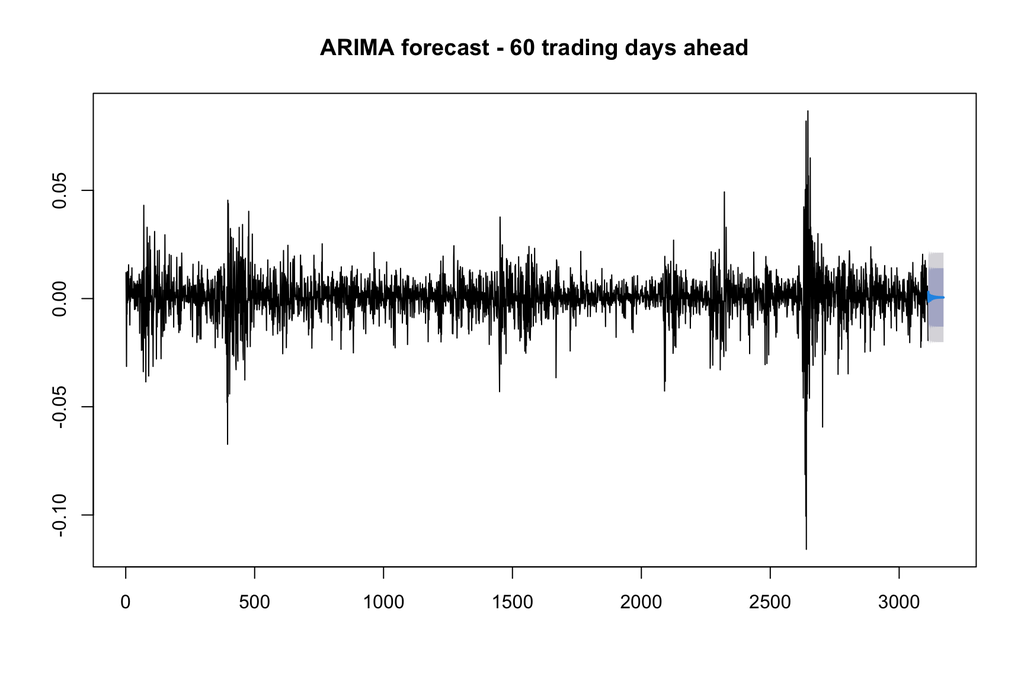

```r
plot(forecast(fit_arima, h = 60),
     main = "ARIMA forecast - 60 trading days ahead")
```

## 8.5 K-means clustering of weekly volatility regimes - R in Action ch. 16

```r
weekly <- apply.weekly(ret$SPY_ret,
                       function(x) c(mean = mean(x), sd = sd(x)))
weekly        <- na.omit(weekly)
weekly_scaled <- scale(coredata(weekly))

set.seed(1234)
nc     <- NbClust(weekly_scaled, min.nc = 2, max.nc = 6, method = "kmeans")
```

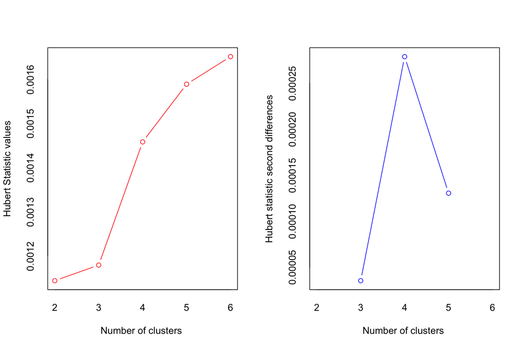

```
## *** : The Hubert index is a graphical method of determining the number of clusters.
##                 In the plot of Hubert index, we seek a significant knee that corresponds to a
##                 significant increase of the value of the measure i.e the significant peak in Hubert
##                 index second differences plot.
##
```

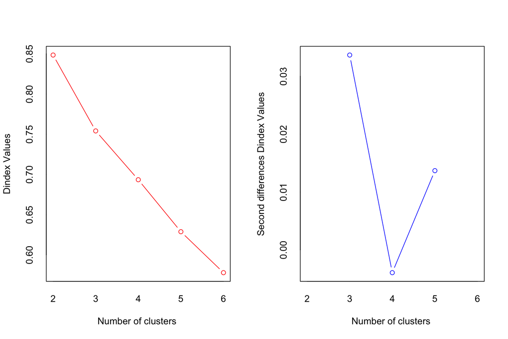

```
## *** : The D index is a graphical method of determining the number of clusters.
##                 In the plot of D index, we seek a significant knee (the significant peak in Dindex
##                 second differences plot) that corresponds to a significant increase of the value of
##                 the measure.
##
## * Among all indices:
## * 11 proposed 2 as the best number of clusters
## * 3 proposed 3 as the best number of clusters
## * 4 proposed 4 as the best number of clusters
## * 4 proposed 5 as the best number of clusters
## * 2 proposed 6 as the best number of clusters
##
##                    ***** Conclusion *****
##
## * According to the majority rule, the best number of clusters is  2
##
##
```

```r
best_k <- as.integer(names(sort(table(nc$Best.n[1, ]), decreasing = TRUE))[1])
if (is.na(best_k) || best_k < 2) best_k <- 3
sprintf("NbClust majority vote: k = %d", best_k)
```

```
## [1] "NbClust majority vote: k = 2"
```

```r
set.seed(1234)
fit_km <- kmeans(weekly_scaled, centers = best_k, nstart = 25)
fit_km$size
```

```
## [1] 629 153
```

```r
round(fit_km$centers, 3)
```

```
##     mean     sd
## 1  0.283 -0.296
## 2 -1.163  1.219
```

```r
regime <- data.frame(date  = index(weekly),
                     mean  = coredata(weekly)[, "mean"],
                     sd    = coredata(weekly)[, "sd"],
                     regime= factor(fit_km$cluster))
aggregate(cbind(mean, sd) ~ regime, data = regime, FUN = mean)
```

| regime | mean | sd |
| --- | --- | --- |
| 1 | 0.001770708 | 0.006462242 |
| 2 | -0.004748017 | 0.016472778 |

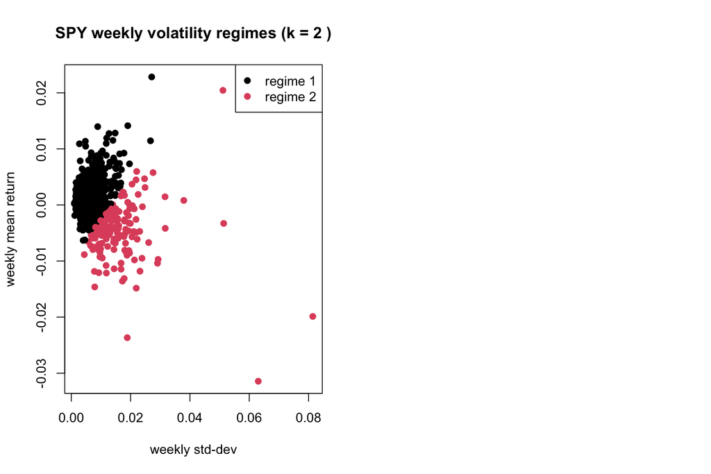

```r
plot(regime$sd, regime$mean, col = regime$regime, pch = 19,
     xlab = "weekly std-dev", ylab = "weekly mean return",
     main = paste("SPY weekly volatility regimes (k =", best_k, ")"))
legend("topright", legend = paste("regime", seq_len(best_k)),
       col = seq_len(best_k), pch = 19)
```

## 8.6 SVM classification - R in Action sec. 17.5

```r
set.seed(1234)
fit_svm <- svm(spy_up ~ spy_lag1 + spy_lag2 + spy_lag3 +
                          qqq_lag1 + iwm_lag1 + gld_lag1 + tlt_lag1 +
                          vix_lag1 + tnx_lag1 + vol20_lag1,
               data = train, probability = TRUE)
summary(fit_svm)
```

```
##
## Call:
## svm(formula = spy_up ~ spy_lag1 + spy_lag2 + spy_lag3 + qqq_lag1 +
##     iwm_lag1 + gld_lag1 + tlt_lag1 + vix_lag1 + tnx_lag1 + vol20_lag1,
##     data = train, probability = TRUE)
##
##
## Parameters:
##    SVM-Type:  C-classification
##  SVM-Kernel:  radial
##        cost:  1
##
## Number of Support Vectors:  2917
##
##  ( 1491 1426 )
##
##
## Number of Classes:  2
##
## Levels:
##  dn up
```

```r
svm_pred <- predict(fit_svm, newdata = valid, probability = TRUE)
svm_prob <- attr(svm_pred, "probabilities")[, "up"]
svm_cm   <- table(actual = valid$spy_up, predicted = svm_pred)
svm_cm
```

```
##       predicted
## actual  dn  up
##     dn   0 382
##     up   0 396
```

```r
svm_acc  <- sum(diag(svm_cm)) / sum(svm_cm)
svm_auc  <- as.numeric(pROC::auc(pROC::roc(valid$spy_up, svm_prob,
                                           quiet = TRUE)))
sprintf("[svm] validation accuracy = %.3f, AUC = %.3f", svm_acc, svm_auc)
```

```
## [1] "[svm] validation accuracy = 0.509, AUC = 0.513"
```

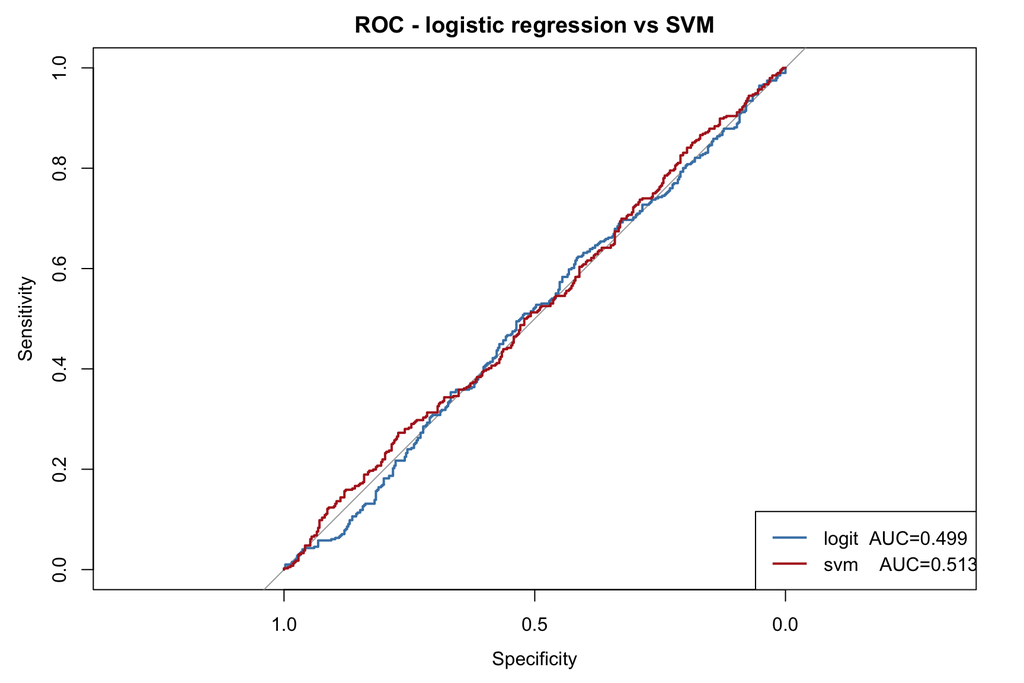

```r
roc_glm <- pROC::roc(valid$spy_up, glm_prob, quiet = TRUE)
roc_svm <- pROC::roc(valid$spy_up, svm_prob, quiet = TRUE)
plot(roc_glm, col = "steelblue", lwd = 2,
     main = "ROC - logistic regression vs SVM")
lines(roc_svm, col = "firebrick", lwd = 2)
legend("bottomright", c(sprintf("logit  AUC=%.3f", glm_auc),
                          sprintf("svm    AUC=%.3f", svm_auc)),
       col = c("steelblue","firebrick"), lwd = 2)
```

# 9 Model comparison

```r
data.frame(
    model     = c("OLS (stepwise)", "ARIMA", "Logistic", "SVM"),
    target    = c("return",  "return",     "direction",  "direction"),
    metric    = c("RMSE",     "RMSE",      "Accuracy",   "Accuracy"),
    value     = c(lm_rmse,    arima_rmse,  glm_acc,      svm_acc),
    secondary = c(lm_dirAcc,  arima_dirAcc, glm_auc,     svm_auc),
    secondary_label = c("dir.Acc","dir.Acc","AUC","AUC"))
```

| model | target | metric | value | secondary | secondary_label |
| --- | --- | --- | --- | --- | --- |
| OLS (stepwise) | return | RMSE | 0.01095195 | 0.4948586 | dir.Acc |
| ARIMA | return | RMSE | 0.01081944 | 0.5115681 | dir.Acc |
| Logistic | direction | Accuracy | 0.51285347 | 0.4987506 | AUC |
| SVM | direction | Accuracy | 0.50899743 | 0.5127717 | AUC |

# 10 Conclusion

1. **Magnitude prediction is hard.** OLS (RMSE = 0.01095) and ARIMA (RMSE = 0.01082) both produce a daily forecast error roughly the size of one ordinary daily move.
2. **Direction prediction is only marginally tractable.** Logistic reaches accuracy = 0.513 / AUC = 0.499; SVM reaches 0.509 / 0.513. Both sit close to the 50% coin-flip.
3. **Volatility regimes are real.** NbClust selects k = 2; the high-vol cluster has *negative* mean weekly return while the low-vol cluster has positive mean - a ‘panic vs calm’ dichotomy that is well documented in the literature.
4. **Statistical tests support the modelling choices** - non-normal returns, prices non-stationary but returns stationary, positive drift confirmed by both parametric and non-parametric tests.
5. **Future work** - technical indicators (RSI, MACD), a credit-spread feature, longer look-backs, gradient-boosted trees, and walk-forward evaluation.

> *The .R version of this report (`Tong_Mo_Project.R`) is the primary deliverable; this `.Rmd` / HTML report is the optional dynamic- report version described in the FRE 6871 walkthrough.*